# Flight Data Exploration

by Samriddhi Singh

```python
#import all needed modules
import pandas as pd
import numpy as np
import seaborn as sb
import matplotlib.pyplot as plt
%matplotlib inline
print('import compleate')
```

```
import compleate
```

```python
df_f=pd.read_csv('airline_delay_causes.csv')
```

# datasets structure

1. year
2. month
3. carrier unique airline company code
4. carrier_name airline company name
5. airport destination airport, airport ID
6. airport_name destination airport, airport name
7. arr_flights number of flights arrived to airport (for given month)
8. arr_del15 number of flights delayed at least 15 min (for given month)
9. carrier_ct number of flights delayed due to air carrier, e.g. maintenance or crew problems, aircraft cleaning, baggage loading, fueling, etc. (for given month)
10. weather_ct number of flights delayed due to weather conditions (for given month)
11. nas_ct number of flights delayed due to National Aviation System, e.g. non-extreme weather conditions, airport operations, heavy traffic volume, and air traffic control (for given month)
12. security_ct number of flights delayed due to security, e.g. evacuation of a terminal or concourse, re-boarding of aircraft because of security breach, inoperative screening equipment and/or long lines in excess of 29 minutes at screening areas (for given month)
13. late_aircraft_ct number of flights delayed due to a previous flight using the same aircraft being late (for given month)
14. arr_cancelled number of calcelled flights (for given month)
15. arr_diverted number of diverted flights (for given month)
16. arr_delay total delay time of arrived flights (in minutes)
17. carrier_delay total delay time of arrived flights due to air carrier (in minutes)
18. weather_delay total delay time of arrived flights due to weather (in minutes)
19. nas_delay total delay time of arrived flights due to National Aviation System (in minutes)
20. security_delay total delay time of arrived flights due to security (in minutes)
21. late_aircraft_delay total delay time of arrived flights due to a previous flight using the same aircraft being late (in minutes)

# my interessts

1) I am inerested in the most common types of carriers  
2) how often a delay happens  
3) what the most famous airports for delays there are  
4) corrolations between delays 5)ct reasons

# what features help my support my interessts?

the column arr_flights carrier and carrier name are going to help me the most

# data assessing

```python
df_f
```

|  | year | month | carrier | carrier_name | airport | airport_name | arr_flights | arr_del15 | carrier_ct | weather_ct | ... | late_aircraft_ct | arr_cancelled | arr_diverted | arr_delay | carrier_delay | weather_delay | nas_delay | security_delay | late_aircraft_delay | Unnamed: 21 |
| --- | --- | --- | --- | --- | --- | --- | --- | --- | --- | --- | --- | --- | --- | --- | --- | --- | --- | --- | --- | --- | --- |
| 0 | 2020 | 4 | 9E | Endeavor Air Inc. | AEX | Alexandria, LA: Alexandria International | 47.0 | 5.0 | 1.78 | 0.00 | ... | 0.00 | 6.0 | 0.0 | 172.0 | 104.0 | 0.0 | 68.0 | 0.0 | 0.0 | NaN |
| 1 | 2020 | 4 | 9E | Endeavor Air Inc. | AGS | Augusta, GA: Augusta Regional at Bush Field | 86.0 | 4.0 | 1.97 | 0.00 | ... | 0.93 | 15.0 | 0.0 | 277.0 | 180.0 | 0.0 | 35.0 | 0.0 | 62.0 | NaN |
| 2 | 2020 | 4 | 9E | Endeavor Air Inc. | ALB | Albany, NY: Albany International | 1.0 | 0.0 | 0.00 | 0.00 | ... | 0.00 | 0.0 | 0.0 | 0.0 | 0.0 | 0.0 | 0.0 | 0.0 | 0.0 | NaN |
| 3 | 2020 | 4 | 9E | Endeavor Air Inc. | ATL | Atlanta, GA: Hartsfield-Jackson Atlanta Intern... | 1314.0 | 56.0 | 36.33 | 2.45 | ... | 9.33 | 288.0 | 1.0 | 4619.0 | 3437.0 | 251.0 | 270.0 | 0.0 | 661.0 | NaN |
| 4 | 2020 | 4 | 9E | Endeavor Air Inc. | ATW | Appleton, WI: Appleton International | 1.0 | 0.0 | 0.00 | 0.00 | ... | 0.00 | 0.0 | 0.0 | 0.0 | 0.0 | 0.0 | 0.0 | 0.0 | 0.0 | NaN |
| ... | ... | ... | ... | ... | ... | ... | ... | ... | ... | ... | ... | ... | ... | ... | ... | ... | ... | ... | ... | ... | ... |
| 1646 | 2020 | 4 | YX | Republic Airline | TPA | Tampa, FL: Tampa International | 12.0 | 0.0 | 0.00 | 0.00 | ... | 0.00 | 8.0 | 0.0 | 0.0 | 0.0 | 0.0 | 0.0 | 0.0 | 0.0 | NaN |
| 1647 | 2020 | 4 | YX | Republic Airline | TUS | Tucson, AZ: Tucson International | 30.0 | 0.0 | 0.00 | 0.00 | ... | 0.00 | 1.0 | 0.0 | 0.0 | 0.0 | 0.0 | 0.0 | 0.0 | 0.0 | NaN |
| 1648 | 2020 | 4 | YX | Republic Airline | TYS | Knoxville, TN: McGhee Tyson | 74.0 | 1.0 | 0.00 | 0.00 | ... | 1.00 | 31.0 | 0.0 | 41.0 | 0.0 | 0.0 | 0.0 | 0.0 | 41.0 | NaN |
| 1649 | 2020 | 4 | YX | Republic Airline | VPS | Valparaiso, FL: Eglin AFB Destin Fort Walton B... | 6.0 | 1.0 | 0.00 | 0.00 | ... | 0.00 | 2.0 | 0.0 | 59.0 | 0.0 | 0.0 | 59.0 | 0.0 | 0.0 | NaN |
| 1650 | 2020 | 4 | YX | Republic Airline | XNA | Fayetteville, AR: Northwest Arkansas Regional | 110.0 | 1.0 | 0.87 | 0.00 | ... | 0.00 | 36.0 | 0.0 | 30.0 | 26.0 | 0.0 | 4.0 | 0.0 | 0.0 | NaN |

1651 rows × 22 columns

```python
df_f.info()
```

```
<class 'pandas.core.frame.DataFrame'>
RangeIndex: 1651 entries, 0 to 1650
Data columns (total 22 columns):
 #   Column               Non-Null Count  Dtype
---  ------               --------------  -----
 0   year                 1651 non-null   int64
 1    month               1651 non-null   int64
 2   carrier              1651 non-null   object
 3   carrier_name         1651 non-null   object
 4   airport              1651 non-null   object
 5   airport_name         1651 non-null   object
 6   arr_flights          1622 non-null   float64
 7   arr_del15            1489 non-null   float64
 8   carrier_ct           1622 non-null   float64
 9    weather_ct          1622 non-null   float64
 10  nas_ct               1622 non-null   float64
 11  security_ct          1622 non-null   float64
 12  late_aircraft_ct     1622 non-null   float64
 13  arr_cancelled        1622 non-null   float64
 14  arr_diverted         1622 non-null   float64
 15   arr_delay           1622 non-null   float64
 16   carrier_delay       1622 non-null   float64
 17  weather_delay        1622 non-null   float64
 18  nas_delay            1622 non-null   float64
 19  security_delay       1622 non-null   float64
 20  late_aircraft_delay  1622 non-null   float64
 21  Unnamed: 21          0 non-null      float64
dtypes: float64(16), int64(2), object(4)
memory usage: 283.9+ KB
```

```python
df_f.describe()
```

|  | year | month | arr_flights | arr_del15 | carrier_ct | weather_ct | nas_ct | security_ct | late_aircraft_ct | arr_cancelled | arr_diverted | arr_delay | carrier_delay | weather_delay | nas_delay | security_delay | late_aircraft_delay | Unnamed: 21 |
| --- | --- | --- | --- | --- | --- | --- | --- | --- | --- | --- | --- | --- | --- | --- | --- | --- | --- | --- |
| count | 1651.0 | 1651.0 | 1622.000000 | 1489.000000 | 1622.000000 | 1622.000000 | 1622.000000 | 1622.000000 | 1622.000000 | 1622.000000 | 1622.000000 | 1622.000000 | 1622.000000 | 1622.000000 | 1622.000000 | 1622.000000 | 1622.000000 | 0.0 |
| mean | 2020.0 | 4.0 | 193.207152 | 6.069846 | 2.772984 | 0.181776 | 1.763046 | 0.017164 | 0.837275 | 80.196054 | 0.183724 | 344.067201 | 215.924168 | 15.295314 | 57.525894 | 0.745993 | 54.575832 | NaN |
| std | 0.0 | 0.0 | 581.055342 | 18.716884 | 9.627878 | 0.626645 | 6.011147 | 0.135505 | 3.496543 | 260.385354 | 0.710914 | 1387.314529 | 978.402835 | 80.193664 | 208.811499 | 6.515835 | 263.422712 | NaN |
| min | 2020.0 | 4.0 | 1.000000 | 0.000000 | 0.000000 | 0.000000 | 0.000000 | 0.000000 | 0.000000 | 0.000000 | 0.000000 | 0.000000 | 0.000000 | 0.000000 | 0.000000 | 0.000000 | 0.000000 | NaN |
| 25% | 2020.0 | 4.0 | 23.000000 | 0.000000 | 0.000000 | 0.000000 | 0.000000 | 0.000000 | 0.000000 | 7.000000 | 0.000000 | 0.000000 | 0.000000 | 0.000000 | 0.000000 | 0.000000 | 0.000000 | NaN |
| 50% | 2020.0 | 4.0 | 52.000000 | 2.000000 | 0.815000 | 0.000000 | 0.000000 | 0.000000 | 0.000000 | 19.000000 | 0.000000 | 47.000000 | 17.000000 | 0.000000 | 0.000000 | 0.000000 | 0.000000 | NaN |
| 75% | 2020.0 | 4.0 | 116.000000 | 5.000000 | 2.000000 | 0.000000 | 1.130000 | 0.000000 | 0.390000 | 47.000000 | 0.000000 | 205.000000 | 119.000000 | 0.000000 | 36.000000 | 0.000000 | 13.000000 | NaN |
| max | 2020.0 | 4.0 | 7237.000000 | 347.000000 | 223.020000 | 9.370000 | 103.600000 | 1.980000 | 64.720000 | 3154.000000 | 9.000000 | 26330.000000 | 20388.000000 | 1680.000000 | 3118.000000 | 115.000000 | 4510.000000 | NaN |

```python
df_f[' month'].value_counts()
```

```
4    1651
Name:  month, dtype: int64
```

```python
df_f
```

|  | year | month | carrier | carrier_name | airport | airport_name | arr_flights | arr_del15 | carrier_ct | weather_ct | ... | late_aircraft_ct | arr_cancelled | arr_diverted | arr_delay | carrier_delay | weather_delay | nas_delay | security_delay | late_aircraft_delay | Unnamed: 21 |
| --- | --- | --- | --- | --- | --- | --- | --- | --- | --- | --- | --- | --- | --- | --- | --- | --- | --- | --- | --- | --- | --- |
| 0 | 2020 | 4 | 9E | Endeavor Air Inc. | AEX | Alexandria, LA: Alexandria International | 47.0 | 5.0 | 1.78 | 0.00 | ... | 0.00 | 6.0 | 0.0 | 172.0 | 104.0 | 0.0 | 68.0 | 0.0 | 0.0 | NaN |
| 1 | 2020 | 4 | 9E | Endeavor Air Inc. | AGS | Augusta, GA: Augusta Regional at Bush Field | 86.0 | 4.0 | 1.97 | 0.00 | ... | 0.93 | 15.0 | 0.0 | 277.0 | 180.0 | 0.0 | 35.0 | 0.0 | 62.0 | NaN |
| 2 | 2020 | 4 | 9E | Endeavor Air Inc. | ALB | Albany, NY: Albany International | 1.0 | 0.0 | 0.00 | 0.00 | ... | 0.00 | 0.0 | 0.0 | 0.0 | 0.0 | 0.0 | 0.0 | 0.0 | 0.0 | NaN |
| 3 | 2020 | 4 | 9E | Endeavor Air Inc. | ATL | Atlanta, GA: Hartsfield-Jackson Atlanta Intern... | 1314.0 | 56.0 | 36.33 | 2.45 | ... | 9.33 | 288.0 | 1.0 | 4619.0 | 3437.0 | 251.0 | 270.0 | 0.0 | 661.0 | NaN |
| 4 | 2020 | 4 | 9E | Endeavor Air Inc. | ATW | Appleton, WI: Appleton International | 1.0 | 0.0 | 0.00 | 0.00 | ... | 0.00 | 0.0 | 0.0 | 0.0 | 0.0 | 0.0 | 0.0 | 0.0 | 0.0 | NaN |
| ... | ... | ... | ... | ... | ... | ... | ... | ... | ... | ... | ... | ... | ... | ... | ... | ... | ... | ... | ... | ... | ... |
| 1646 | 2020 | 4 | YX | Republic Airline | TPA | Tampa, FL: Tampa International | 12.0 | 0.0 | 0.00 | 0.00 | ... | 0.00 | 8.0 | 0.0 | 0.0 | 0.0 | 0.0 | 0.0 | 0.0 | 0.0 | NaN |
| 1647 | 2020 | 4 | YX | Republic Airline | TUS | Tucson, AZ: Tucson International | 30.0 | 0.0 | 0.00 | 0.00 | ... | 0.00 | 1.0 | 0.0 | 0.0 | 0.0 | 0.0 | 0.0 | 0.0 | 0.0 | NaN |
| 1648 | 2020 | 4 | YX | Republic Airline | TYS | Knoxville, TN: McGhee Tyson | 74.0 | 1.0 | 0.00 | 0.00 | ... | 1.00 | 31.0 | 0.0 | 41.0 | 0.0 | 0.0 | 0.0 | 0.0 | 41.0 | NaN |
| 1649 | 2020 | 4 | YX | Republic Airline | VPS | Valparaiso, FL: Eglin AFB Destin Fort Walton B... | 6.0 | 1.0 | 0.00 | 0.00 | ... | 0.00 | 2.0 | 0.0 | 59.0 | 0.0 | 0.0 | 59.0 | 0.0 | 0.0 | NaN |
| 1650 | 2020 | 4 | YX | Republic Airline | XNA | Fayetteville, AR: Northwest Arkansas Regional | 110.0 | 1.0 | 0.87 | 0.00 | ... | 0.00 | 36.0 | 0.0 | 30.0 | 26.0 | 0.0 | 4.0 | 0.0 | 0.0 | NaN |

1651 rows × 22 columns

```python
sum(df_f.duplicated())
```

```
0
```

```python
sum(df_f.arr_flights.isnull())
```

```
29
```

```python
df_f.year.value_counts()
```

```
2020    1651
Name: year, dtype: int64
```

```python
df_f[df_f.arr_del15.isnull()]
```

|  | year | month | carrier | carrier_name | airport | airport_name | arr_flights | arr_del15 | carrier_ct | weather_ct | ... | late_aircraft_ct | arr_cancelled | arr_diverted | arr_delay | carrier_delay | weather_delay | nas_delay | security_delay | late_aircraft_delay | Unnamed: 21 |
| --- | --- | --- | --- | --- | --- | --- | --- | --- | --- | --- | --- | --- | --- | --- | --- | --- | --- | --- | --- | --- | --- |
| 5 | 2020 | 4 | 9E | Endeavor Air Inc. | AUS | Austin, TX: Austin - Bergstrom International | 1.0 | NaN | 0.0 | 0.0 | ... | 0.0 | 1.0 | 0.0 | 0.0 | 0.0 | 0.0 | 0.0 | 0.0 | 0.0 | NaN |
| 12 | 2020 | 4 | 9E | Endeavor Air Inc. | BNA | Nashville, TN: Nashville International | 2.0 | NaN | 0.0 | 0.0 | ... | 0.0 | 2.0 | 0.0 | 0.0 | 0.0 | 0.0 | 0.0 | 0.0 | 0.0 | NaN |
| 19 | 2020 | 4 | 9E | Endeavor Air Inc. | CAE | Columbia, SC: Columbia Metropolitan | NaN | NaN | NaN | NaN | ... | NaN | NaN | NaN | NaN | NaN | NaN | NaN | NaN | NaN | NaN |
| 20 | 2020 | 4 | 9E | Endeavor Air Inc. | CAK | Akron, OH: Akron-Canton Regional | 1.0 | NaN | 0.0 | 0.0 | ... | 0.0 | 1.0 | 0.0 | 0.0 | 0.0 | 0.0 | 0.0 | 0.0 | 0.0 | NaN |
| 23 | 2020 | 4 | 9E | Endeavor Air Inc. | CHS | Charleston, SC: Charleston AFB/International | 7.0 | NaN | 0.0 | 0.0 | ... | 0.0 | 7.0 | 0.0 | 0.0 | 0.0 | 0.0 | 0.0 | 0.0 | 0.0 | NaN |
| ... | ... | ... | ... | ... | ... | ... | ... | ... | ... | ... | ... | ... | ... | ... | ... | ... | ... | ... | ... | ... | ... |
| 1594 | 2020 | 4 | YX | Republic Airline | DFW | Dallas/Fort Worth, TX: Dallas/Fort Worth Inter... | 1.0 | NaN | 0.0 | 0.0 | ... | 0.0 | 1.0 | 0.0 | 0.0 | 0.0 | 0.0 | 0.0 | 0.0 | 0.0 | NaN |
| 1603 | 2020 | 4 | YX | Republic Airline | HRL | Harlingen/San Benito, TX: Valley International | NaN | NaN | NaN | NaN | ... | NaN | NaN | NaN | NaN | NaN | NaN | NaN | NaN | NaN | NaN |
| 1614 | 2020 | 4 | YX | Republic Airline | LFT | Lafayette, LA: Lafayette Regional Paul Fournet... | NaN | NaN | NaN | NaN | ... | NaN | NaN | NaN | NaN | NaN | NaN | NaN | NaN | NaN | NaN |
| 1621 | 2020 | 4 | YX | Republic Airline | MKE | Milwaukee, WI: General Mitchell International | 7.0 | NaN | 0.0 | 0.0 | ... | 0.0 | 7.0 | 0.0 | 0.0 | 0.0 | 0.0 | 0.0 | 0.0 | 0.0 | NaN |
| 1632 | 2020 | 4 | YX | Republic Airline | PNS | Pensacola, FL: Pensacola International | 6.0 | NaN | 0.0 | 0.0 | ... | 0.0 | 6.0 | 0.0 | 0.0 | 0.0 | 0.0 | 0.0 | 0.0 | 0.0 | NaN |

162 rows × 22 columns

based on this information we can see that all 1651 enteries of this dataset are from April 2020

## data assessing summary

# data wrangling

```python
#coping are data set for wrangling
df=df_f.copy()
```

def:get all the indexes of the rows with arr_flights and remove these

code:

```python
df[df.arr_flights.isnull()].index
#these enteries dont have any usefull data=>so they need to be droped
```

```
Int64Index([  19,   54,   56,  330,  341,  352,  356,  372,  373,  374,  380,
             391,  410,  414,  437,  465,  474,  477,  525,  846, 1265, 1314,
            1320, 1341, 1520, 1539, 1580, 1603, 1614],
           dtype='int64')
```

```python
df = df.drop(df.index[[19,   54,   56,  330,  341,  352,  356,  372,  373,  374,  380,
             391,  410,  414,  437,  465,  474,  477,  525,  846, 1265, 1314,
            1320, 1341, 1520, 1539, 1580, 1603, 1614]], axis=0)
```

test:

```python
sum(df.arr_flights.isnull())
```

```
0
```

```python
df[df.arr_flights.isnull()]
```

|  | year | month | carrier | carrier_name | airport | airport_name | arr_flights | arr_del15 | carrier_ct | weather_ct | ... | late_aircraft_ct | arr_cancelled | arr_diverted | arr_delay | carrier_delay | weather_delay | nas_delay | security_delay | late_aircraft_delay | Unnamed: 21 |
| --- | --- | --- | --- | --- | --- | --- | --- | --- | --- | --- | --- | --- | --- | --- | --- | --- | --- | --- | --- | --- | --- |

0 rows × 22 columns

def:rename ' month','arr_del15' ,' weather_ct', ' arr_delay', ' carrier_delay'

code:

```python
df = df.rename(columns = {' month':'month','arr_del15':'delay_15', ' weather_ct': 'weather_ct',
                ' arr_delay': 'arr_delay', ' carrier_delay': 'carrier_delay'})
```

test:

```python
df
```

|  | year | month | carrier | carrier_name | airport | airport_name | arr_flights | delay_15 | carrier_ct | weather_ct | ... | late_aircraft_ct | arr_cancelled | arr_diverted | arr_delay | carrier_delay | weather_delay | nas_delay | security_delay | late_aircraft_delay | Unnamed: 21 |
| --- | --- | --- | --- | --- | --- | --- | --- | --- | --- | --- | --- | --- | --- | --- | --- | --- | --- | --- | --- | --- | --- |
| 0 | 2020 | 4 | 9E | Endeavor Air Inc. | AEX | Alexandria, LA: Alexandria International | 47.0 | 5.0 | 1.78 | 0.00 | ... | 0.00 | 6.0 | 0.0 | 172.0 | 104.0 | 0.0 | 68.0 | 0.0 | 0.0 | NaN |
| 1 | 2020 | 4 | 9E | Endeavor Air Inc. | AGS | Augusta, GA: Augusta Regional at Bush Field | 86.0 | 4.0 | 1.97 | 0.00 | ... | 0.93 | 15.0 | 0.0 | 277.0 | 180.0 | 0.0 | 35.0 | 0.0 | 62.0 | NaN |
| 2 | 2020 | 4 | 9E | Endeavor Air Inc. | ALB | Albany, NY: Albany International | 1.0 | 0.0 | 0.00 | 0.00 | ... | 0.00 | 0.0 | 0.0 | 0.0 | 0.0 | 0.0 | 0.0 | 0.0 | 0.0 | NaN |
| 3 | 2020 | 4 | 9E | Endeavor Air Inc. | ATL | Atlanta, GA: Hartsfield-Jackson Atlanta Intern... | 1314.0 | 56.0 | 36.33 | 2.45 | ... | 9.33 | 288.0 | 1.0 | 4619.0 | 3437.0 | 251.0 | 270.0 | 0.0 | 661.0 | NaN |
| 4 | 2020 | 4 | 9E | Endeavor Air Inc. | ATW | Appleton, WI: Appleton International | 1.0 | 0.0 | 0.00 | 0.00 | ... | 0.00 | 0.0 | 0.0 | 0.0 | 0.0 | 0.0 | 0.0 | 0.0 | 0.0 | NaN |
| ... | ... | ... | ... | ... | ... | ... | ... | ... | ... | ... | ... | ... | ... | ... | ... | ... | ... | ... | ... | ... | ... |
| 1646 | 2020 | 4 | YX | Republic Airline | TPA | Tampa, FL: Tampa International | 12.0 | 0.0 | 0.00 | 0.00 | ... | 0.00 | 8.0 | 0.0 | 0.0 | 0.0 | 0.0 | 0.0 | 0.0 | 0.0 | NaN |
| 1647 | 2020 | 4 | YX | Republic Airline | TUS | Tucson, AZ: Tucson International | 30.0 | 0.0 | 0.00 | 0.00 | ... | 0.00 | 1.0 | 0.0 | 0.0 | 0.0 | 0.0 | 0.0 | 0.0 | 0.0 | NaN |
| 1648 | 2020 | 4 | YX | Republic Airline | TYS | Knoxville, TN: McGhee Tyson | 74.0 | 1.0 | 0.00 | 0.00 | ... | 1.00 | 31.0 | 0.0 | 41.0 | 0.0 | 0.0 | 0.0 | 0.0 | 41.0 | NaN |
| 1649 | 2020 | 4 | YX | Republic Airline | VPS | Valparaiso, FL: Eglin AFB Destin Fort Walton B... | 6.0 | 1.0 | 0.00 | 0.00 | ... | 0.00 | 2.0 | 0.0 | 59.0 | 0.0 | 0.0 | 59.0 | 0.0 | 0.0 | NaN |
| 1650 | 2020 | 4 | YX | Republic Airline | XNA | Fayetteville, AR: Northwest Arkansas Regional | 110.0 | 1.0 | 0.87 | 0.00 | ... | 0.00 | 36.0 | 0.0 | 30.0 | 26.0 | 0.0 | 4.0 | 0.0 | 0.0 | NaN |

1622 rows × 22 columns

def: drop Unnamed: 21

code:

```python
df = df.drop('Unnamed: 21', axis=1)
```

test:

```python
df.info()
```

```
<class 'pandas.core.frame.DataFrame'>
Int64Index: 1622 entries, 0 to 1650
Data columns (total 21 columns):
 #   Column               Non-Null Count  Dtype
---  ------               --------------  -----
 0   year                 1622 non-null   int64
 1   month                1622 non-null   int64
 2   carrier              1622 non-null   object
 3   carrier_name         1622 non-null   object
 4   airport              1622 non-null   object
 5   airport_name         1622 non-null   object
 6   arr_flights          1622 non-null   float64
 7   delay_15             1489 non-null   float64
 8   carrier_ct           1622 non-null   float64
 9   weather_ct           1622 non-null   float64
 10  nas_ct               1622 non-null   float64
 11  security_ct          1622 non-null   float64
 12  late_aircraft_ct     1622 non-null   float64
 13  arr_cancelled        1622 non-null   float64
 14  arr_diverted         1622 non-null   float64
 15  arr_delay            1622 non-null   float64
 16  carrier_delay        1622 non-null   float64
 17  weather_delay        1622 non-null   float64
 18  nas_delay            1622 non-null   float64
 19  security_delay       1622 non-null   float64
 20  late_aircraft_delay  1622 non-null   float64
dtypes: float64(15), int64(2), object(4)
memory usage: 278.8+ KB
```

code:

```python
df = df.drop(df[df['delay_15'].isnull()].index, axis=0)
df['delay_15'].replace('None', 0, inplace=True)
```

test:

```python
sum(df.delay_15.isnull())
```

```
0
```

```python
df.info()
```

```
<class 'pandas.core.frame.DataFrame'>
Int64Index: 1489 entries, 0 to 1650
Data columns (total 21 columns):
 #   Column               Non-Null Count  Dtype
---  ------               --------------  -----
 0   year                 1489 non-null   int64
 1   month                1489 non-null   int64
 2   carrier              1489 non-null   object
 3   carrier_name         1489 non-null   object
 4   airport              1489 non-null   object
 5   airport_name         1489 non-null   object
 6   arr_flights          1489 non-null   float64
 7   delay_15             1489 non-null   float64
 8   carrier_ct           1489 non-null   float64
 9   weather_ct           1489 non-null   float64
 10  nas_ct               1489 non-null   float64
 11  security_ct          1489 non-null   float64
 12  late_aircraft_ct     1489 non-null   float64
 13  arr_cancelled        1489 non-null   float64
 14  arr_diverted         1489 non-null   float64
 15  arr_delay            1489 non-null   float64
 16  carrier_delay        1489 non-null   float64
 17  weather_delay        1489 non-null   float64
 18  nas_delay            1489 non-null   float64
 19  security_delay       1489 non-null   float64
 20  late_aircraft_delay  1489 non-null   float64
dtypes: float64(15), int64(2), object(4)
memory usage: 255.9+ KB
```

```python
df
```

|  | year | month | carrier | carrier_name | airport | airport_name | arr_flights | delay_15 | carrier_ct | weather_ct | ... | security_ct | late_aircraft_ct | arr_cancelled | arr_diverted | arr_delay | carrier_delay | weather_delay | nas_delay | security_delay | late_aircraft_delay |
| --- | --- | --- | --- | --- | --- | --- | --- | --- | --- | --- | --- | --- | --- | --- | --- | --- | --- | --- | --- | --- | --- |
| 0 | 2020 | 4 | 9E | Endeavor Air Inc. | AEX | Alexandria, LA: Alexandria International | 47.0 | 5.0 | 1.78 | 0.00 | ... | 0.0 | 0.00 | 6.0 | 0.0 | 172.0 | 104.0 | 0.0 | 68.0 | 0.0 | 0.0 |
| 1 | 2020 | 4 | 9E | Endeavor Air Inc. | AGS | Augusta, GA: Augusta Regional at Bush Field | 86.0 | 4.0 | 1.97 | 0.00 | ... | 0.0 | 0.93 | 15.0 | 0.0 | 277.0 | 180.0 | 0.0 | 35.0 | 0.0 | 62.0 |
| 2 | 2020 | 4 | 9E | Endeavor Air Inc. | ALB | Albany, NY: Albany International | 1.0 | 0.0 | 0.00 | 0.00 | ... | 0.0 | 0.00 | 0.0 | 0.0 | 0.0 | 0.0 | 0.0 | 0.0 | 0.0 | 0.0 |
| 3 | 2020 | 4 | 9E | Endeavor Air Inc. | ATL | Atlanta, GA: Hartsfield-Jackson Atlanta Intern... | 1314.0 | 56.0 | 36.33 | 2.45 | ... | 0.0 | 9.33 | 288.0 | 1.0 | 4619.0 | 3437.0 | 251.0 | 270.0 | 0.0 | 661.0 |
| 4 | 2020 | 4 | 9E | Endeavor Air Inc. | ATW | Appleton, WI: Appleton International | 1.0 | 0.0 | 0.00 | 0.00 | ... | 0.0 | 0.00 | 0.0 | 0.0 | 0.0 | 0.0 | 0.0 | 0.0 | 0.0 | 0.0 |
| ... | ... | ... | ... | ... | ... | ... | ... | ... | ... | ... | ... | ... | ... | ... | ... | ... | ... | ... | ... | ... | ... |
| 1646 | 2020 | 4 | YX | Republic Airline | TPA | Tampa, FL: Tampa International | 12.0 | 0.0 | 0.00 | 0.00 | ... | 0.0 | 0.00 | 8.0 | 0.0 | 0.0 | 0.0 | 0.0 | 0.0 | 0.0 | 0.0 |
| 1647 | 2020 | 4 | YX | Republic Airline | TUS | Tucson, AZ: Tucson International | 30.0 | 0.0 | 0.00 | 0.00 | ... | 0.0 | 0.00 | 1.0 | 0.0 | 0.0 | 0.0 | 0.0 | 0.0 | 0.0 | 0.0 |
| 1648 | 2020 | 4 | YX | Republic Airline | TYS | Knoxville, TN: McGhee Tyson | 74.0 | 1.0 | 0.00 | 0.00 | ... | 0.0 | 1.00 | 31.0 | 0.0 | 41.0 | 0.0 | 0.0 | 0.0 | 0.0 | 41.0 |
| 1649 | 2020 | 4 | YX | Republic Airline | VPS | Valparaiso, FL: Eglin AFB Destin Fort Walton B... | 6.0 | 1.0 | 0.00 | 0.00 | ... | 0.0 | 0.00 | 2.0 | 0.0 | 59.0 | 0.0 | 0.0 | 59.0 | 0.0 | 0.0 |
| 1650 | 2020 | 4 | YX | Republic Airline | XNA | Fayetteville, AR: Northwest Arkansas Regional | 110.0 | 1.0 | 0.87 | 0.00 | ... | 0.0 | 0.00 | 36.0 | 0.0 | 30.0 | 26.0 | 0.0 | 4.0 | 0.0 | 0.0 |

1489 rows × 21 columns

```python
#now we export our clean df to a csv
df.to_csv('cleaned_flight_data.csv')
```

# Exploration

## Univariate

In this section, investigate distributions of individual variables. If you see unusual points or outliers, take a deeper look to clean things up and prepare yourself to look at relationships between variables.

```python
df.carrier_name.value_counts()
```

```
SkyWest Airlines Inc.      239
Envoy Air                  135
Delta Air Lines Inc.       116
American Airlines Inc.      98
Mesa Airlines Inc.          94
Southwest Airlines Co.      89
Frontier Airlines Inc.      87
PSA Airlines Inc.           86
United Air Lines Inc.       79
Endeavor Air Inc.           74
ExpressJet Airlines LLC     72
Alaska Airlines Inc.        71
Republic Airline            71
Allegiant Air               69
JetBlue Airways             59
Spirit Air Lines            43
Hawaiian Airlines Inc.       7
Name: carrier_name, dtype: int64
```

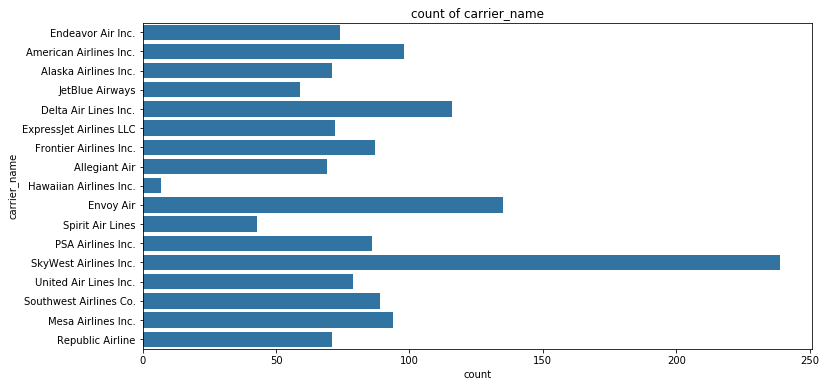

```python
#setting the size for our plot
plt.figure(figsize = [12, 6])
blue=sb.color_palette()[0]
#creating a bar chart with seaborns countplot function
sb.countplot(data = df, y = 'carrier_name',color=blue);

plt.title('count of carrier_name');
```

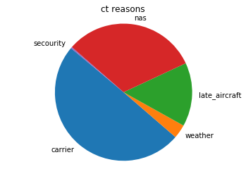

```python
#our labels
label ='carrier', 'weather','late_aircraft','nas','secourity'
#storring all our datapoints in a list
data = [df.carrier_ct.mean(),df.weather_ct.mean(),df.late_aircraft_ct.mean(),
               df.nas_ct.mean(),df.security_ct.mean()]
#and plotting them
plt.pie(data, labels=label, startangle=140)
plt.axis('equal')
plt.title('ct reasons');
```

**TakeAway** : here we can observe a pie chart with the mean of 5 ct reasons.carrier ct has the highsest mean(again carrier_ct means:number of flights delayed due to air carrier, e.g. maintenance or crew problems, aircraft cleaning, baggage loading, fueling, etc.),while secourity can be barly seen.Wich is suprising to me since I expected secourity to be one of the largest

```python
df.info()
```

```
<class 'pandas.core.frame.DataFrame'>
Int64Index: 1489 entries, 0 to 1650
Data columns (total 21 columns):
 #   Column               Non-Null Count  Dtype
---  ------               --------------  -----
 0   year                 1489 non-null   int64
 1   month                1489 non-null   int64
 2   carrier              1489 non-null   object
 3   carrier_name         1489 non-null   object
 4   airport              1489 non-null   object
 5   airport_name         1489 non-null   object
 6   arr_flights          1489 non-null   float64
 7   delay_15             1489 non-null   float64
 8   carrier_ct           1489 non-null   float64
 9   weather_ct           1489 non-null   float64
 10  nas_ct               1489 non-null   float64
 11  security_ct          1489 non-null   float64
 12  late_aircraft_ct     1489 non-null   float64
 13  arr_cancelled        1489 non-null   float64
 14  arr_diverted         1489 non-null   float64
 15  arr_delay            1489 non-null   float64
 16  carrier_delay        1489 non-null   float64
 17  weather_delay        1489 non-null   float64
 18  nas_delay            1489 non-null   float64
 19  security_delay       1489 non-null   float64
 20  late_aircraft_delay  1489 non-null   float64
dtypes: float64(15), int64(2), object(4)
memory usage: 295.9+ KB
```

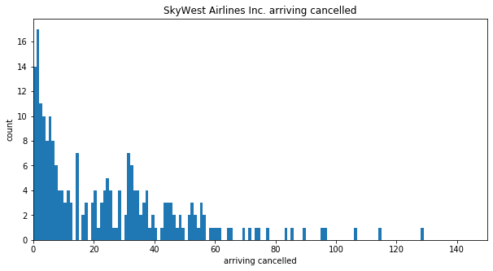

```python
plt.figure(figsize = [10, 5])
#costumising the length of the x axsis
plt.xlim(0,150)
#srtting our own bins so you see more
bin_edges = np.arange(0, df[df.carrier_name=='SkyWest Airlines Inc.'].arr_cancelled.max()+0.5, 1);
#plotting the hist
plt.hist(df[df.carrier_name=='SkyWest Airlines Inc.'].arr_cancelled,bins = bin_edges);
plt.xlabel('arriving cancelled')
plt.ylabel('count');
plt.title('SkyWest Airlines Inc. arriving cancelled');
```

**TakeAway**: In the first plot we could see that SkyWest Airlines Inc. had the highest count so when I took a deeper look into this carrier you can see a hist about the srriving cancellment and the count of this.The highest count appeares to be between 0 and 20.

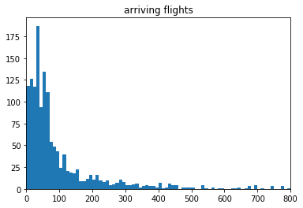

```python
#costumizing the bins
bin_edges = np.arange(0, df['arr_flights'].max()+1, 10);
#costumising the length of the x axsis
plt.xlim(0,800);
#plotting the hist
plt.hist(x=df['arr_flights'],bins=bin_edges);
plt.title('arriving flights');
```

**TakeAway:** here I plottet a histogramm of arriving flights.on the x axis is the value and on the y axis is the count.based on this you can see that datapoints between 0 and 100.Meaning that values between 0 and 100 are most common

## Univariate summary

**Discuss the distribution(s) of your variable(s) of interest. Were there any unusual points? Did you need to perform any transformations?**

I did not do any transformations and nothing too unusual came across with these plots

some interessting observation was though that so little percent of ct is on secourity,since in my expirences secourity always was a delay

**Of the features you investigated, were there any unusual distributions? Did you perform any operations on the data to tidy, adjust, or change the form of the data? If so, why did you do this?**

I could see that skywest airlains was by far the moost common carrier and I did not perform any operations

## Bivariate Exploration

In this section, investigate relationships between pairs of variables in your data. Make sure the variables that you cover here have been introduced in some fashion in the previous section (univariate exploration).

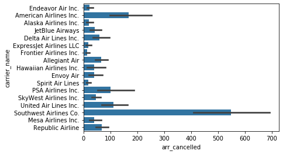

```python
blue=sb.color_palette()[0]
sb.barplot(data = df.sort_values(by=['carrier']),
           y = 'carrier_name', x="arr_cancelled", color = blue)
# the color parameter sets all bars to blue instead of the defoult palette
```

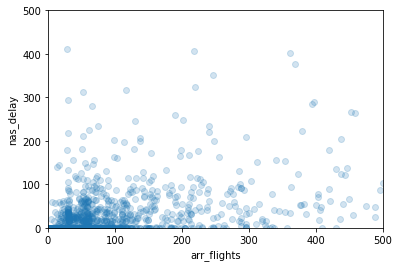

```python
#alpha parameter make the less busy dataploins transperant
plt.scatter(x=df.arr_flights,y=df.nas_delay,alpha=1/5)

#setting personalized x and y lenghts
plt.xlim(0,500)
plt.ylim(0,500)
plt.ylabel('nas_delay')
plt.xlabel('arr_flights')
```

**TakeAway** here their does not seem to be a corrolation with arriving flights and nas delay,wich I thick is interessting since the more planes comming the more you can expect nas delays to happen,but not according to our data

```python
weather_ct_mean=df.weather_ct.describe()[1]
```

```python
df.weather_ct.describe()
```

```
count    1489.000000
mean        0.198012
std         0.651587
min         0.000000
25%         0.000000
50%         0.000000
75%         0.000000
max         9.370000
Name: weather_ct, dtype: float64
```

```python
df[df.weather_ct>=weather_ct_mean].delay_15
```

```
3       56.0
36      48.0
55      12.0
77       2.0
98      18.0
        ...
1616     2.0
1618     4.0
1622     2.0
1623     3.0
1631    11.0
Name: delay_15, Length: 225, dtype: float64
```

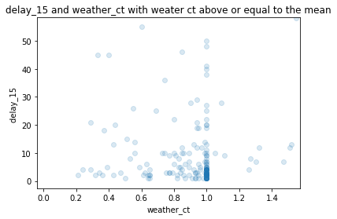

```python
#plotting our selected data
plt.scatter(x=df[df.weather_ct>=weather_ct_mean].weather_ct,y=df[df.weather_ct>=weather_ct_mean].delay_15,alpha=1/6)
#costumizing the plot
scale_factor = 0.16
xmin, xmax = plt.xlim()
ymin, ymax = plt.ylim()
plt.xlim(xmin * scale_factor, xmax * scale_factor)
plt.ylim(ymin * scale_factor, ymax * scale_factor)
#some labels and titles
plt.ylabel('delay_15 ')
plt.xlabel('weather_ct')
plt.title('delay_15 and weather_ct with weater ct above or equal to the mean');
```

**TakeAway**: you can see a strong line going from 1.0 upwards with the darkest point around 1.00 at x and 0-10 at y.This plot was made by getting all the enteries with a weather_ct above or equal to the mean.And from these enteries I dot the delay_15 and weather_ct.and even if you can see the line that is no corrolotion

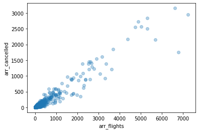

```python
#using the regplot for this scatterplot
sb.regplot(data = df, x = 'arr_flights', y = 'arr_cancelled', fit_reg = False,
           x_jitter = 0.5, y_jitter = 0.2, scatter_kws = {'alpha' : 1/3})
```

**TakeAway**: here you can see a positiv reletionship between arrving cancelled and arriving flights.

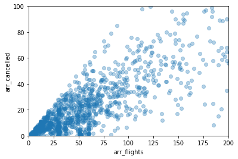

```python
#simply a zoom in
plt.xlim(0,200)
plt.ylim(0,100)
sb.regplot(data = df, x = 'arr_flights', y = 'arr_cancelled', fit_reg = False,
           x_jitter = 0.5, y_jitter = 0.2, scatter_kws = {'alpha' : 1/3})
```

**TakeAway**: In the second plot i zoomed in on the busy part just to get a better idea.

```python
#getting the needed enteries
a=df[df.carrier_name=='SkyWest Airlines Inc.' ]
b=df[df.carrier_name=='Envoy Air' ]
c=df[df.carrier_name=='Delta Air Lines Inc.' ]
#merging them togrther using concat
a_b_c=pd.concat([a,b,c])
a_b_c.carrier_name.value_counts()
```

```
SkyWest Airlines Inc.    239
Envoy Air                135
Delta Air Lines Inc.     116
Name: carrier_name, dtype: int64
```

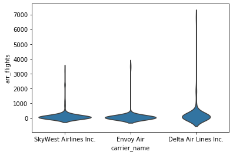

```python
#setting the color
base_color = sb.color_palette()[0]
#with inner=none we just remove the smaller boxplot in the middle of the violin plot
sb.violinplot(data = a_b_c, x = 'carrier_name', y = 'arr_flights',inner=None,color=base_color)
```

**TakeAway:** Here you can see the 3 most common carriers in a violin plot.what informations you can see is that the lenth repersents wich values there are and the the thickness repersents how many counts were in this value.So in this plot you can see that the mean of arriving flights is quiet less but the thin line can go for beond

**talk about some of the relationships you observed in this part of the investigation. How did the feature(s) of interest vary with other features in the dataset?**

their seem to be a lot of differences in carriers like shown in bivariate plot1(that hawian airline was the least common but did not have the least cancallations)and also in the violin plot the mean was far less then the max.I did not expect such a big differnce

**Did you observe any interesting relationships between the other features (not the main feature(s) of interest)?**

yes the first plot were you can see the mean of the counts in carriers was the the answer to my interessts

## Multivariate Exploration

Create plots of three or more variables to investigate your data even further. Make sure that your investigations are justified, and follow from your work in the previous sections.

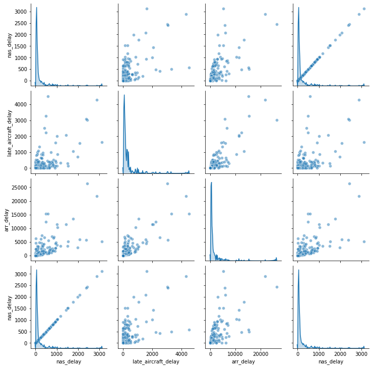

```python
#plotting a faceting with a pairplot
sb.pairplot(df,
             vars = ['nas_delay','late_aircraft_delay','arr_delay','nas_delay' ],
             diag_kind = 'kde', plot_kws = {'alpha': 0.5},palette="ch:2.5,-.2,dark=.3")
```

**TakeAway**: here we can see wich delays have corrolations with other delays.most obvious positiv corrolations are between late aircraft and arr_delay,nas_delay and arr_delay

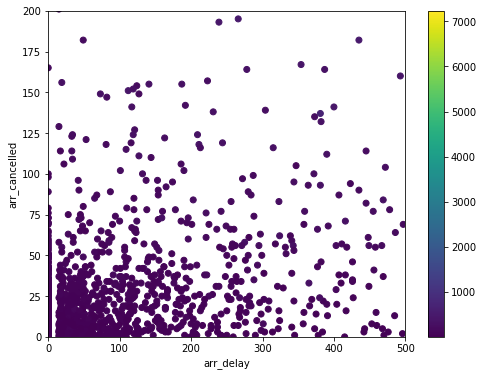

```python
plt.figure(figsize=(8,6))
plt.xlim(0,500)

plt.ylim(0,200)

plt.scatter(data = df, x = 'arr_delay', y = 'arr_cancelled', c = 'arr_flights')
#creates the color plot on the right side
plt.colorbar()
plt.ylabel('arr_cancelled')
plt.xlabel('arr_delay')
```

**TakeAway:** between arrive delay and arr_cancelled there does not seem to be a blurry postiv corrolation while the arriving flight seem the be rather steady

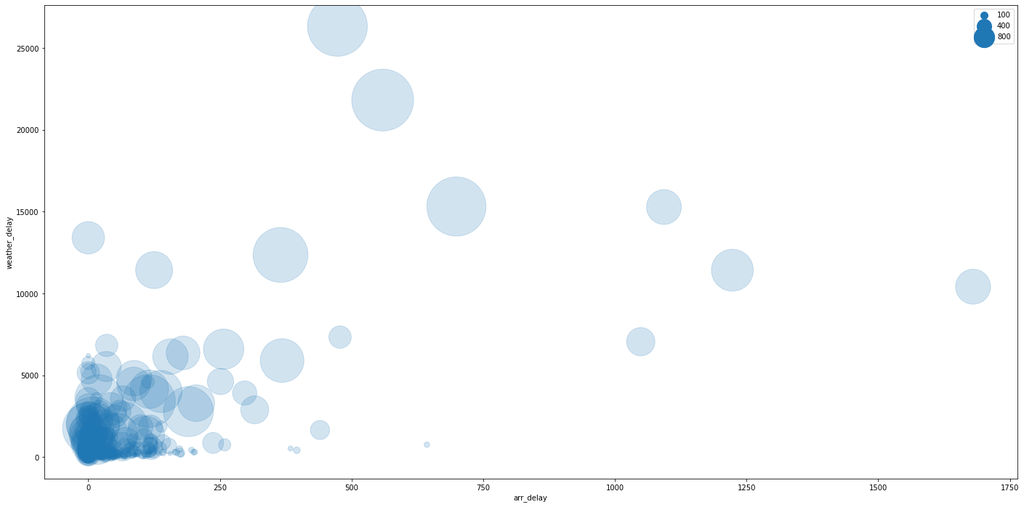

```python
plt.figure(figsize = [24, 12])
plt.scatter(data = df, x = 'weather_delay', y = 'arr_delay', s = 'arr_flights',alpha=1/5)

# dummy series for adding legend
sizes = [100,400,800]
base_color = sb.color_palette()[0]
legend_obj = []
for s in sizes:
    legend_obj.append(plt.scatter([], [], s = s, color = base_color))
plt.legend(legend_obj, sizes)
plt.ylabel('weather_delay')
plt.xlabel('arr_delay')
```

**TakeAway:** in this plot you can see a posiuv corroletion between weather_delay and arriving delay.you can also see a some randomness in arrivingflights.Meaning that there is no designatet value for arr_delay and weather delay to achive the smallest amount of arriving flights

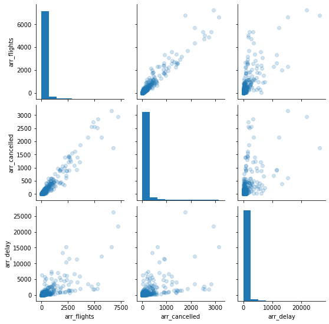

```python
g = sb.PairGrid(data = df, vars = ['arr_flights', 'arr_cancelled', 'arr_delay'])
g.map_diag(plt.hist)
#creates a scatter for the off diagnole values
g.map_offdiag(plt.scatter,alpha=1/5)
```

**Takeaway**: here you can see the corrolation between several arr variables.The clearest corrolation is between arr_cancelled arr_flights(positiv corrolation)

```python
df.info()
```

```
<class 'pandas.core.frame.DataFrame'>
Int64Index: 1489 entries, 0 to 1650
Data columns (total 21 columns):
 #   Column               Non-Null Count  Dtype
---  ------               --------------  -----
 0   year                 1489 non-null   int64
 1   month                1489 non-null   int64
 2   carrier              1489 non-null   object
 3   carrier_name         1489 non-null   object
 4   airport              1489 non-null   object
 5   airport_name         1489 non-null   object
 6   arr_flights          1489 non-null   float64
 7   delay_15             1489 non-null   float64
 8   carrier_ct           1489 non-null   float64
 9   weather_ct           1489 non-null   float64
 10  nas_ct               1489 non-null   float64
 11  security_ct          1489 non-null   float64
 12  late_aircraft_ct     1489 non-null   float64
 13  arr_cancelled        1489 non-null   float64
 14  arr_diverted         1489 non-null   float64
 15  arr_delay            1489 non-null   float64
 16  carrier_delay        1489 non-null   float64
 17  weather_delay        1489 non-null   float64
 18  nas_delay            1489 non-null   float64
 19  security_delay       1489 non-null   float64
 20  late_aircraft_delay  1489 non-null   float64
dtypes: float64(15), int64(2), object(4)
memory usage: 295.9+ KB
```

here we can see that there is a corrolation between the variables arr_delay late aircraft and nas delay

**Talk about some of the relationships you observed in this part of the investigation. Were there features that strengthened each other in terms of looking at your feature(s) of interest?**

the second facething plot (especially the corrolation between arriving flight and cancelation of flights)supported sthe scatter plot were I especially plottet these two variables.

**Were there any interesting or surprising interactions between features?**

we could see in plot 1 that some delays have infact relationships since in bivary plot 2 we did not see that(also becouse these were only 2 variables)

```python
df
```

|  | year | month | carrier | carrier_name | airport | airport_name | arr_flights | delay_15 | carrier_ct | weather_ct | ... | security_ct | late_aircraft_ct | arr_cancelled | arr_diverted | arr_delay | carrier_delay | weather_delay | nas_delay | security_delay | late_aircraft_delay |
| --- | --- | --- | --- | --- | --- | --- | --- | --- | --- | --- | --- | --- | --- | --- | --- | --- | --- | --- | --- | --- | --- |
| 0 | 2020 | 4 | 9E | Endeavor Air Inc. | AEX | Alexandria, LA: Alexandria International | 47.0 | 5.0 | 1.78 | 0.00 | ... | 0.0 | 0.00 | 6.0 | 0.0 | 172.0 | 104.0 | 0.0 | 68.0 | 0.0 | 0.0 |
| 1 | 2020 | 4 | 9E | Endeavor Air Inc. | AGS | Augusta, GA: Augusta Regional at Bush Field | 86.0 | 4.0 | 1.97 | 0.00 | ... | 0.0 | 0.93 | 15.0 | 0.0 | 277.0 | 180.0 | 0.0 | 35.0 | 0.0 | 62.0 |
| 2 | 2020 | 4 | 9E | Endeavor Air Inc. | ALB | Albany, NY: Albany International | 1.0 | 0.0 | 0.00 | 0.00 | ... | 0.0 | 0.00 | 0.0 | 0.0 | 0.0 | 0.0 | 0.0 | 0.0 | 0.0 | 0.0 |
| 3 | 2020 | 4 | 9E | Endeavor Air Inc. | ATL | Atlanta, GA: Hartsfield-Jackson Atlanta Intern... | 1314.0 | 56.0 | 36.33 | 2.45 | ... | 0.0 | 9.33 | 288.0 | 1.0 | 4619.0 | 3437.0 | 251.0 | 270.0 | 0.0 | 661.0 |
| 4 | 2020 | 4 | 9E | Endeavor Air Inc. | ATW | Appleton, WI: Appleton International | 1.0 | 0.0 | 0.00 | 0.00 | ... | 0.0 | 0.00 | 0.0 | 0.0 | 0.0 | 0.0 | 0.0 | 0.0 | 0.0 | 0.0 |
| ... | ... | ... | ... | ... | ... | ... | ... | ... | ... | ... | ... | ... | ... | ... | ... | ... | ... | ... | ... | ... | ... |
| 1646 | 2020 | 4 | YX | Republic Airline | TPA | Tampa, FL: Tampa International | 12.0 | 0.0 | 0.00 | 0.00 | ... | 0.0 | 0.00 | 8.0 | 0.0 | 0.0 | 0.0 | 0.0 | 0.0 | 0.0 | 0.0 |
| 1647 | 2020 | 4 | YX | Republic Airline | TUS | Tucson, AZ: Tucson International | 30.0 | 0.0 | 0.00 | 0.00 | ... | 0.0 | 0.00 | 1.0 | 0.0 | 0.0 | 0.0 | 0.0 | 0.0 | 0.0 | 0.0 |
| 1648 | 2020 | 4 | YX | Republic Airline | TYS | Knoxville, TN: McGhee Tyson | 74.0 | 1.0 | 0.00 | 0.00 | ... | 0.0 | 1.00 | 31.0 | 0.0 | 41.0 | 0.0 | 0.0 | 0.0 | 0.0 | 41.0 |
| 1649 | 2020 | 4 | YX | Republic Airline | VPS | Valparaiso, FL: Eglin AFB Destin Fort Walton B... | 6.0 | 1.0 | 0.00 | 0.00 | ... | 0.0 | 0.00 | 2.0 | 0.0 | 59.0 | 0.0 | 0.0 | 59.0 | 0.0 | 0.0 |
| 1650 | 2020 | 4 | YX | Republic Airline | XNA | Fayetteville, AR: Northwest Arkansas Regional | 110.0 | 1.0 | 0.87 | 0.00 | ... | 0.0 | 0.00 | 36.0 | 0.0 | 30.0 | 26.0 | 0.0 | 4.0 | 0.0 | 0.0 |

1489 rows × 21 columns